# Cohorts and Cultural Change

Stephen Vaisey

stephen.vaisey@duke.edu

**Duke University**

Department of Sociology

Department of Political Science

March 2, 2026

# Objectives

# Previous work

## Orienting example

## Competing models of cultural change

**Active updating:** individuals follow the zeitgeist

**Settled dispositions:** demographic replacement

## And yes, before you ask…

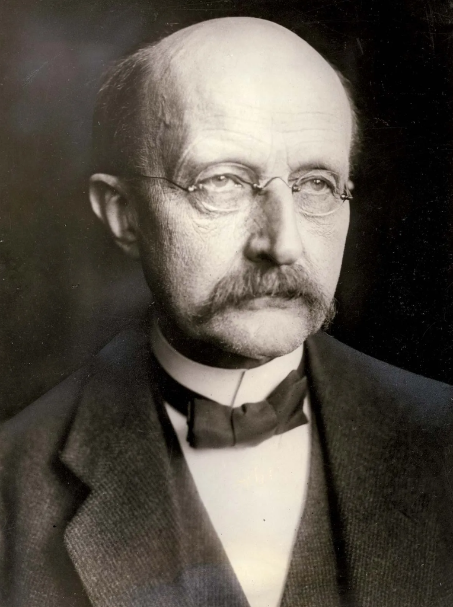

I *am*, in fact, familiar with Max Planck’s (almost) quote that science advances one funeral at a time.

## The age-period-cohort problem

*Age effects* (developmental), *period effects* (current events), and *cohort* *effects* (shared early life experiences) are analytically separable but you only have two “real” variables to estimate three effects.

**Two approaches**

- Repeated cross section decompositions (e.g., GSS 1972-2024)
- Panel studies of individual change (or not!) (e.g., GSS, BHPS)

These can also be applied to unstructured data.

Underwood, T., Kiley, K., Shang, W., & Vaisey, S. (2022). Cohort Succession Explains Most Change in Literary Culture. *Sociological Science*, 9, 184–205.

## Repeated cross-sections: HAPC

$$\begin{aligned}y_{ipc} &\sim \cal{N}(\mu_{ipc},\sigma) \\\mu_{ipc} &= \beta_0 + \beta_1(\text{age}_{ipc}) + \beta_2(\text{age}_{ipc}^2) +
\alpha_{\text{PER}[p]} + \gamma_{\text{COH}[c]} \\
\alpha &\sim \cal{N}(0, \sigma_{\alpha}) \\
\gamma &\sim \cal{N}(0, \sigma_{\gamma})
\end{aligned}$$

So $\sigma_{\alpha}^2$ tells you how much *periods* vary and $\sigma_{\gamma}^2$ tells you how much *cohorts* vary so it’s reasonable to ask about their relative importance. We can quantify this as the proportion:

$$\delta = \frac{\sigma_{\gamma}^2}{\sigma_{\gamma}^2 + \sigma_{\alpha}^2}$$

Vaisey, S., & Lizardo, O. (2016). Cultural Fragmentation or Acquired Dispositions? A New Approach to Accounting for Patterns of Cultural Change.

## Repeated cross-sections: results

About **85% of this change is cohort replacement**.

Vaisey, S., & Lizardo, O. (2016). Cultural Fragmentation or Acquired Dispositions? A New Approach to Accounting for Patterns of Cultural Change.

## Across 164 variables

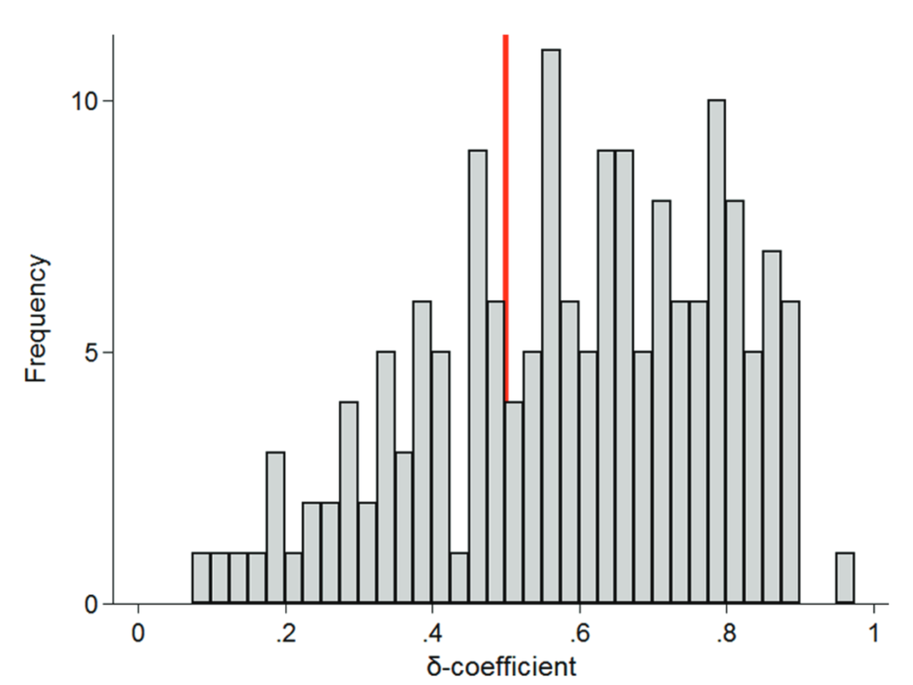

Vaisey, S., & Lizardo, O. (2016). Cultural Fragmentation or Acquired Dispositions? A New Approach to Accounting for Patterns of Cultural Change.

## Previous work with panel data

Kiley, K., & Vaisey, S. (2020). Measuring Stability and Change in Personal Culture Using Panel Data. *American Sociological Review*, *85*(3), 477–506.

Vaisey, S., & Kiley, K. (2021). A Model-Based Method for Detecting Persistent Cultural Change Using Panel Data. *Sociological Science*, *8*, 83–95.

Keskintürk, T., Bello, P., & Vaisey, S. (2025). The promises and pitfalls of using panel data to understand individual belief change. *Political Psychology*.

## The intuition

[figure not shown]

Kiley, K., & Vaisey, S. (2020). Measuring Stability and Change in Personal Culture Using Panel Data. *American Sociological Review*, *85*(3), 477–506.

## The original model

$$\begin{aligned}
y_{i3} &\sim \mathcal{N}(\mu_i, \sigma) \\
\mu_i &= \alpha + \phi \beta y_{i2} + (1-\phi)\beta y_{i1}
\end{aligned}$$

- $\beta$ is the extent to which wave 3 is predictable *at all* on the basis of previous responses
- $\phi$ is how “memoryless” (i.e., Markov-like) the process is; when it’s closer to 1, that is evidence of **persistent change**; when it’s closer to .5, that’s evidence of **stability with error**

Kiley, K., & Vaisey, S. (2020). Measuring Stability and Change in Personal Culture Using Panel Data. *American Sociological Review*, *85*(3), 477–506.

## Selected estimates

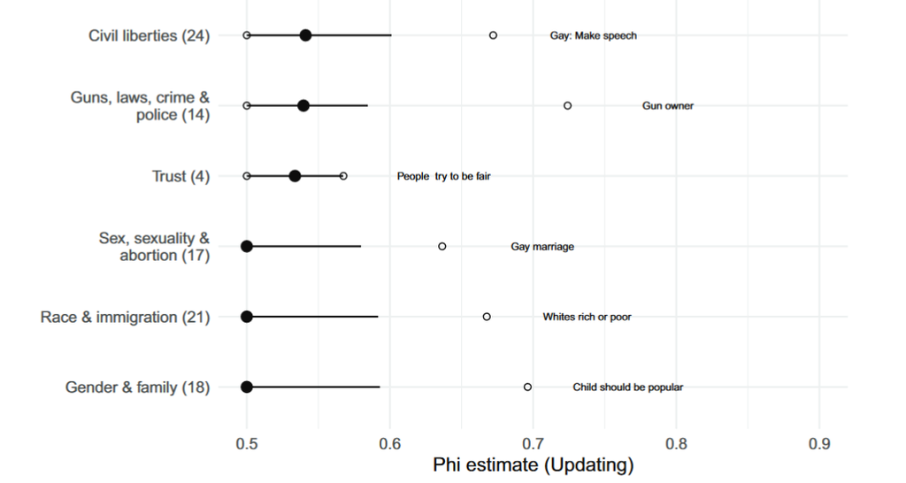

Kiley, K., & Vaisey, S. (2020). Measuring Stability and Change in Personal Culture Using Panel Data. *American Sociological Review*, *85*(3), 477–506.

## Same idea, different model

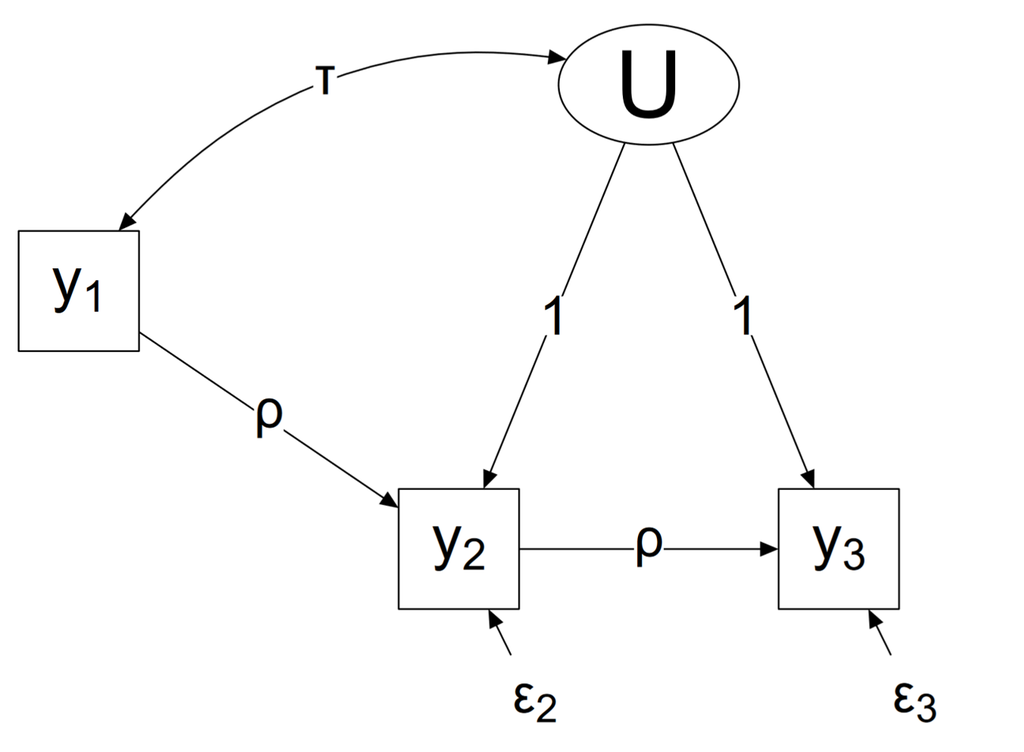

Vaisey, S., & Kiley, K. (2021). A Model-Based Method for Detecting Persistent Cultural Change Using Panel Data. *Sociological Science*, *8*, 83–95.

## Results: tournament of models

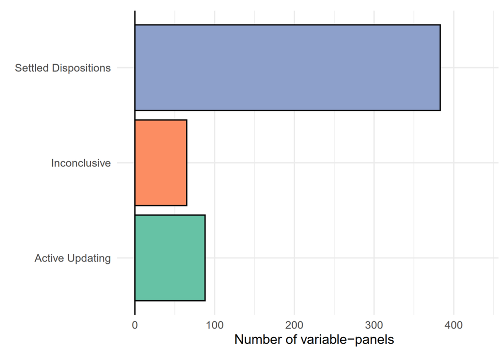

Vaisey, S., & Kiley, K. (2021). A Model-Based Method for Detecting Persistent Cultural Change Using Panel Data. *Sociological Science*, *8*, 83–95.

## Recent debate

[figure not shown]

## Clarifying the question

From *adjudication* to *quantification*

From “does this variable change?” to “how many people are changing and by how much?”

# New work

with Kevin Kiley (NC State), Turgut Keskinturk (Duke), and Achim Edelmann (Sciences Po)

## *How much* does modeling change improve prediction?

## Data and strategy

20 questions from British Household Panel Survey, 8 waves, 1991 to 2009

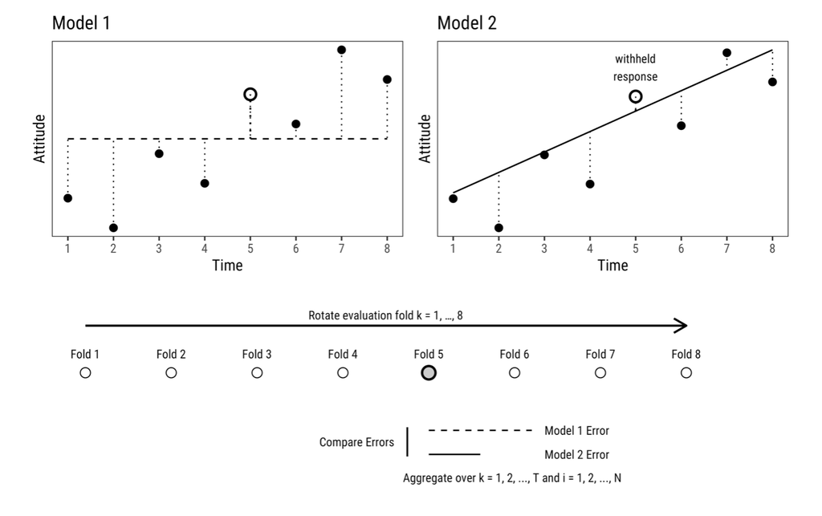

## Incremental predictive gain from change

Defining the individual-level quantity:

$$\text{IPGC}_{it} = \frac{(E^B_{it})^2 - (E^C_{it})^2}{Var(Y)}$$

## Incremental predictive gain from change

Aggregated value

$$\text{AIPGC} = R_C^2 - R_B^2$$

## Example 1: Government reflects the will of the people

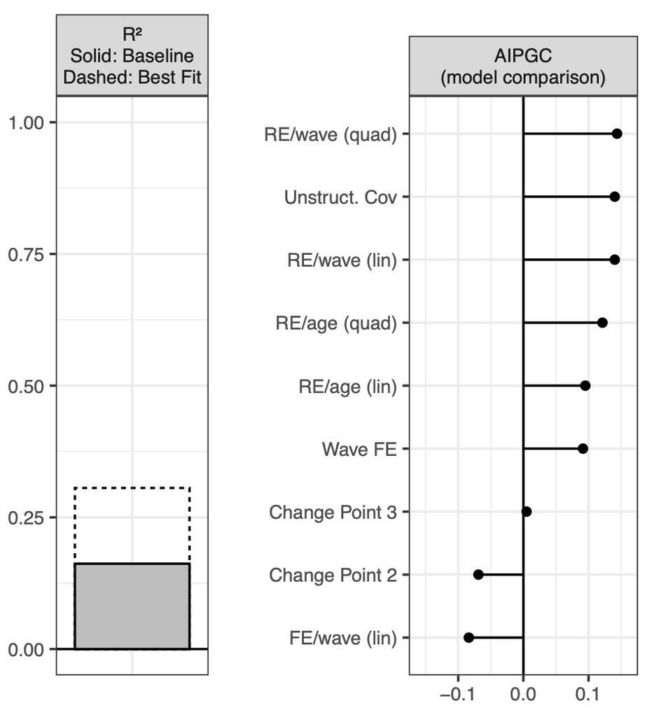

## Example 1: Government reflects the will of the people

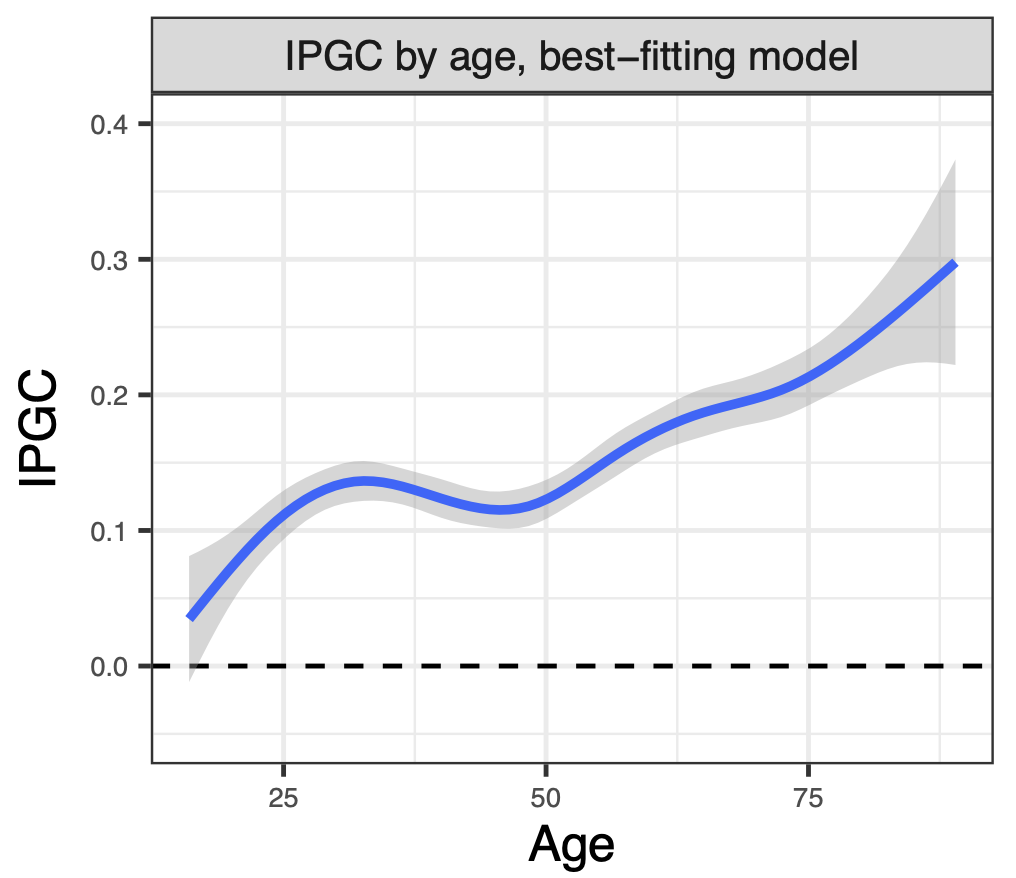

## Example 2: It is the govt’s reponsibility to provide jobs

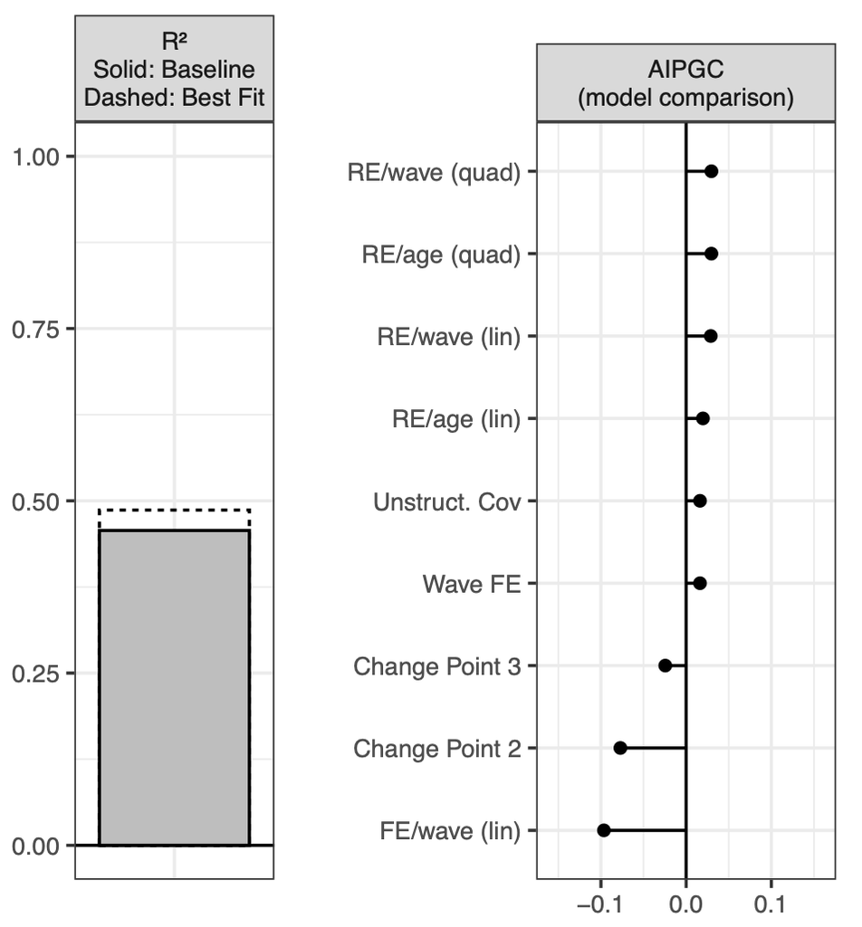

## Example 2: It is the govt’s reponsibility to provide jobs

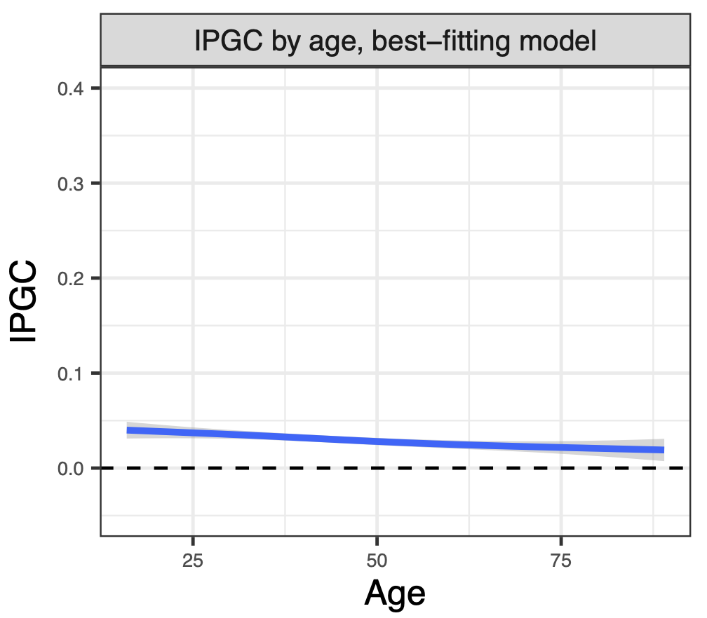

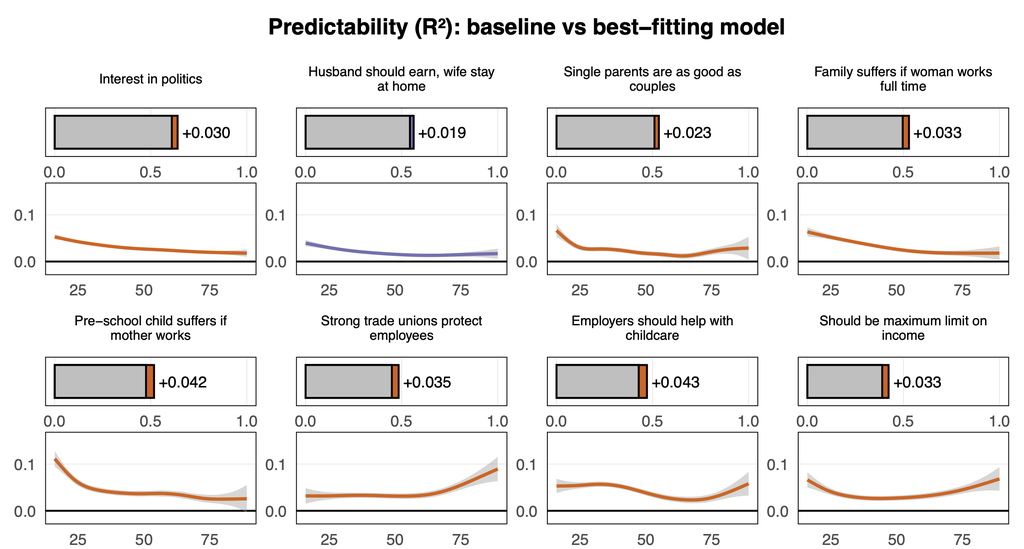

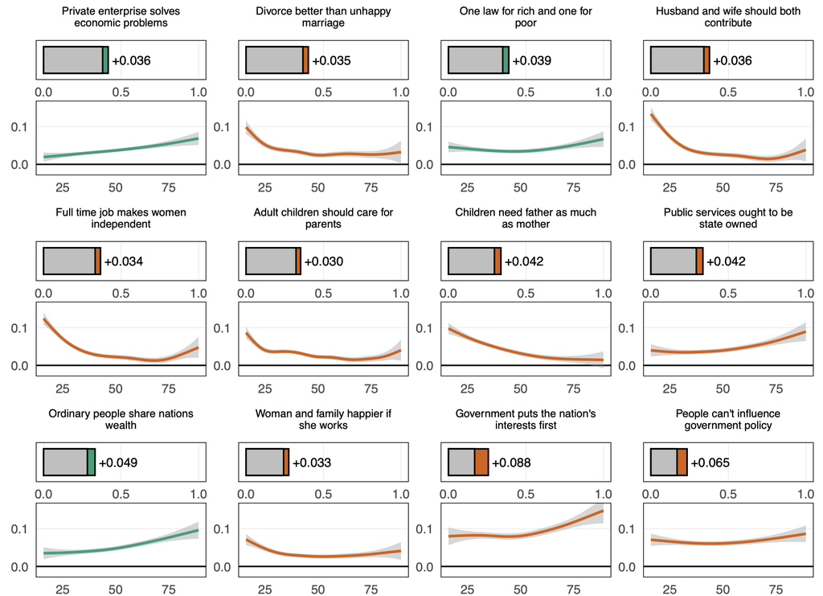

## Conclusions

1. Important not to confuse **cultural change** with **individual change**
2. Most (not all!) recent cultural change seems to be cohort replacement
3. Social salience may override (not just “sensitive period”)
4. We need *quantification* not just adjudication
5. New data sources have pros and cons

## Thank you!

Website: vaiseys.github.io

Bluesky: @vaiseys

# Appendix

## Sample US GSS questions (1972-present)

- “Please tell me whether or not you think it should be possible for a pregnant woman to obtain a legal abortion if the woman wants it for any reason?”
- “Tell me if you agree or disagree with this statement: Most men are better suited emotionally for politics than are most women.”
- “If some people in your community suggested that a book [someone] wrote which said Blacks are inferior should be taken out of your public library, would you favor removing this book, or not?”
- “Are we spending too much, too little, or about the right amount on improving and protecting the environment?”
- “What about sexual relations between two adults of the same sex–do you think it is always wrong, almost always wrong, wrong only sometimes, or not wrong at all?”

Vaisey, S., & Lizardo, O. (2016). Cultural Fragmentation or Acquired Dispositions? A New Approach to Accounting for Patterns of Cultural Change.